# ggplot2, exercise

Matthias Templ  
R Summer School, Vorau 2017

### Example 1:

In the following examples, some ggplot2 functions are to be tested and some parameters to be adjusted. Use the data set *Cars93*.

```r
data(Cars93, package = "MASS")
```

More detailed information on the data you obtained with the open the help (**?Cars93**).

- Create a scatter plot of the variable *MPG.city* dependend of *Weight*.
- Color the points in blue.
- Color the points according to variable *Origin*.

### Solution 1:

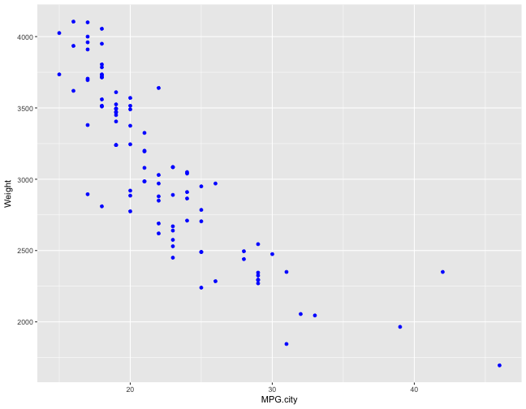

```r
require("ggplot2")
g <- ggplot(Cars93, aes(x=MPG.city, y=Weight))
g <- g + geom_point(color="blue"); g
```

### Solution 1:

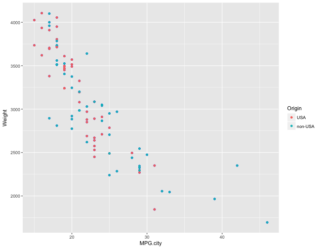

```r
g + geom_point(aes(color=Origin))
```

### Example 2:

- Create a boxplot of **MPG.city**.
- Add points with colouring according to **Origin**.
- Make a scatter plot of variable **Weight** dependend on **Horsepower**.
- Add a regression line.
- Apply it for all groups of variable *Origin*

### Solution 2:

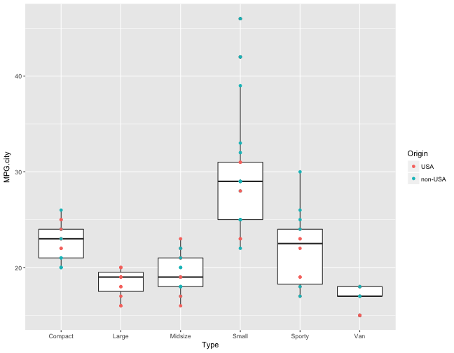

```r
g <- ggplot(Cars93,aes(x=Type,y=MPG.city))
g <- g + geom_boxplot()
g + geom_point(aes(color=Origin))
```

### Solution 2:

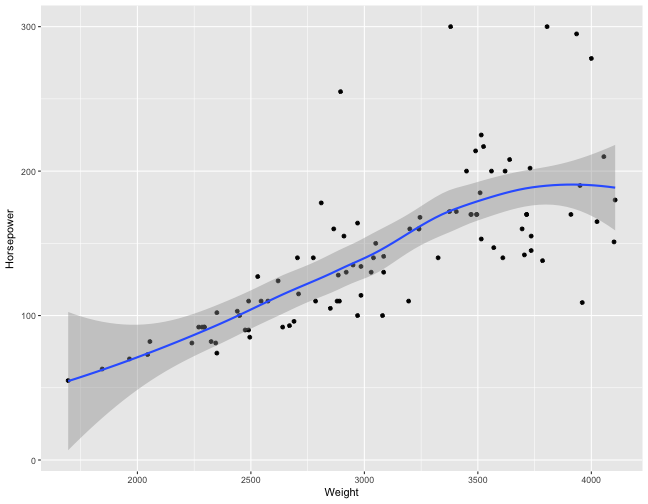

```r
g <- ggplot(Cars93,aes(x=Weight,y=Horsepower))
g <- g + geom_point()
g + geom_smooth()
```

### Solution 2:

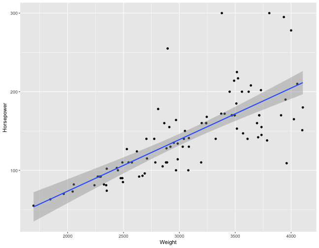

```r
g <- g + geom_smooth(method="lm")
g
```

### Solution 2:

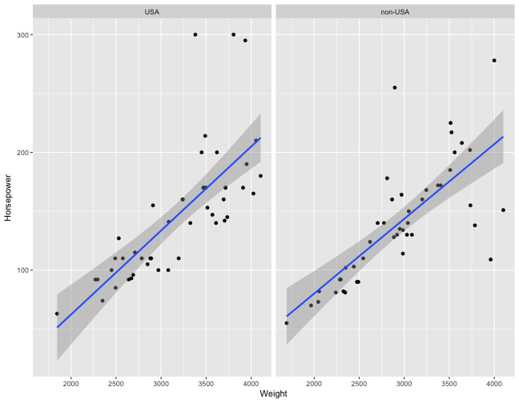

```r
g <- g + facet_wrap(~ Origin)
g
```

### Example 3: Fine tuning

For the last graphic,

- take the black/white theme
- took the symbol size according to the Max.Price and introduce alpha transparency.
- increase all font sizes.
- take the font “Times” (New Roman) for annotation
- For tax reasons, assume that horsepower smaller than 90 are important. Add a (red) line at horsepower 90 and add a grid line as well as make an axis notation for 90.

### Solution 3:

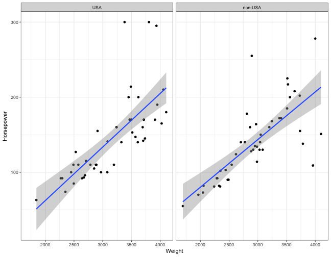

```r
g <- g + theme_bw()
g
```

### Solution 3:

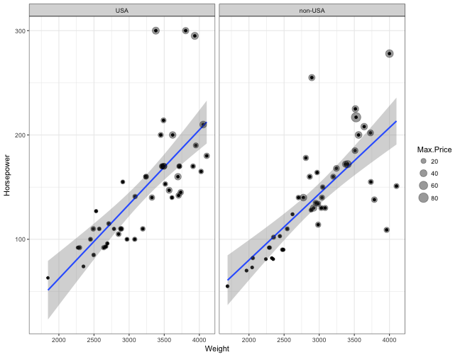

```r
g <- g + geom_point(aes(size = Max.Price), alpha =0.4)
g
```

### Solution 3:

Increase font sizes

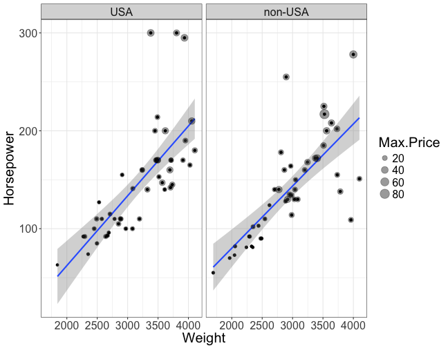

```r
g <- g + theme(text = element_text(size=20))
g
```

### Solution 3:

Font Times New Roman

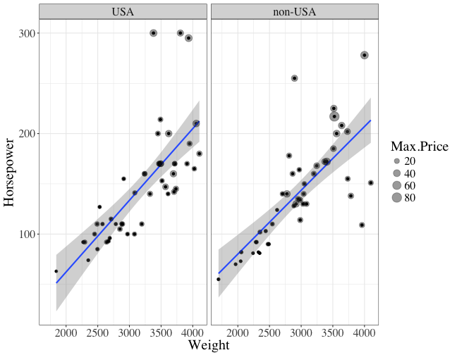

```r
g <- g + theme(text = element_text(family="Times"))
g
```

### Solution 3:

Add (red) line

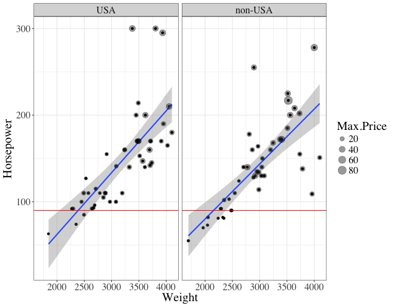

```r
g <- g + geom_hline(yintercept = 90, colour="red")
g
```

### Solution 3:

New axis notation

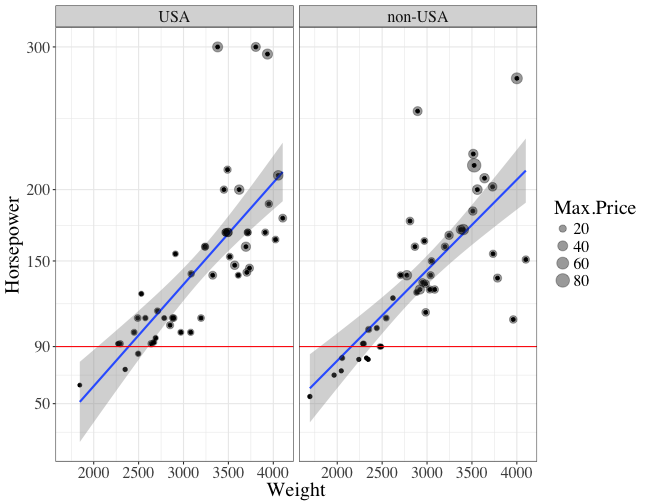

```r
g <- g + scale_y_continuous(breaks = c(50, 90, 150, 200, 300))
g
```

### Example 4: tidy data?

From this data set

```r
olddata_wide <- read.table(header=TRUE, text='
 time sex control cond1 cond2
       1   M     7.9  12.3  10.7
       2   F     6.3  10.6  11.1
       3   F     9.5  13.1  13.8
       4   M    11.5  13.4  12.9
')
```

### Example 4: tidy data?

produce this graphics:

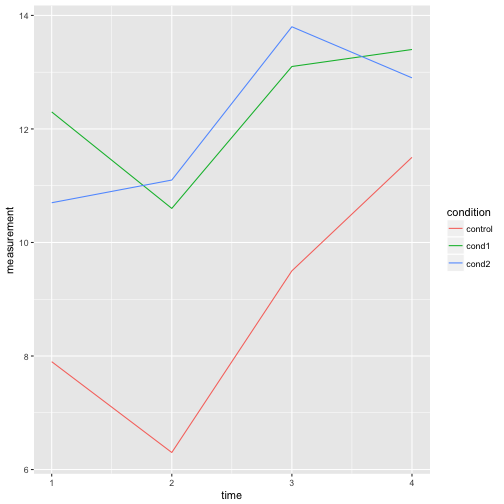

### Example 4: tidy data?

produce this graphics:

```r
library(tidyr)
## ggplot2 needs tidy data!
## use e.g. reshape2::melt or
## tidy::gather
data_long <- gather(olddata_wide, condition, measurement, control:cond2, factor_key=TRUE)
ggplot(data_long, aes(x = time, y = measurement, group=condition, color=condition)) + geom_line()
```

### Example 5: Themes - just for fun :)

```r
install.packages("extrafont")
install.packages("xkcd")
## look at
vignette("xkcd-intro")
```

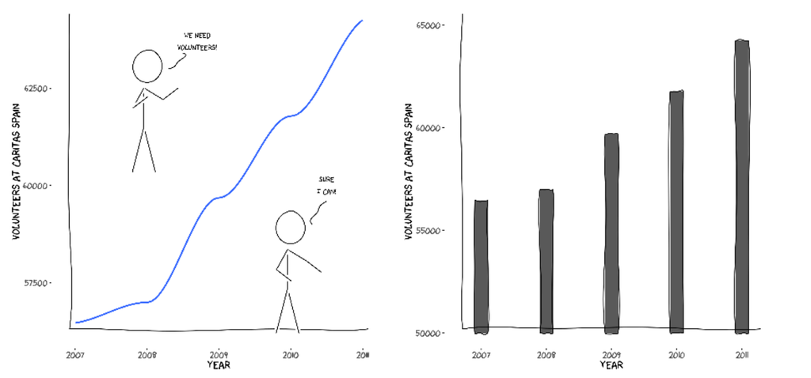